# Variación estacional en el número de especies de mamíferos terrestres en el Volcán Barva-Caribe

Raquel Bone Guzmán

12/3/2020

**Repositorio en GitHub**: https://github.com/raquelbone/mamiferos_barva.git

## 1. ¿Cuál es la pregunta específica de investigación?

El equipo de Tropical Ecology, Assessment and Monitoring (TEAM) Network mantiene desde 2008 un programa de monitoreo de la comunidad de mamíferos terrestres a lo largo del gradiente altitudinal desde las tierras altas del Barva hacia las bajas del Caribe. Este monitoreo mediante cámaras trampa se lleva a cabo anualmente en periodos de muestreo delimitados de enero a agosto, con el fin de evitar daños en el equipo los meses extremadamente lluviosos. La base de datos puede solicitarse desde el sitio web http://www.teamnetwork.org/ el cual están migrando a https://www.wildlifeinsights.org/team-network.

Dentro de toda la información que se puede extraer de estos datos, en este trabajo tenemos como pregunta si existe un efecto estacional (evaluado por mes) en la riqueza de especies de mamíferos terrestres presentes en la región, tomando en cuenta la variación en la temperatura y las fases lunares asociadas a los registros.

Para realizar el análisis primero vamos a extraer y ordenar la base de datos, y luego vamos a explorar Modelos Aditivos Generalizados Mixtos (GAMM), ya que tomaremos cada año de muestreo como un factor aleatorio dentro del modelo.

## 2. ¿Cuáles son las variables relevantes y cuál es su relación, conocida y/o hipotética?

Queremos saber si nuestra variable respuesta, la riqueza de especies de mamíferos terrestres (R) presentes en el gradiente del Volcán Barva-Caribe, varía estacionalmente según las condiciones ambientales. Evaluaremos esta estacionalidad por mes (M) de enero a agosto, tomando en cuenta la variación de la temperatura (TE) y la fase lunar (L), la cual tiene un marcado efecto en los patrones de actividad de los mamíferos nocturnos y catemerales (Botts et al. 2020). Tomaremos en cuenta que cada año (A) estos factores son cambiantes o pueden variar para cada mes. También consideramos que, dependiendo del año (factor aleatorio), la riqueza de especies de mamíferos encontradas en un mismo mes (factor fijo, e.g. enero) puede ser variable.

A continuación un diagrama causal de hipótesis para aclarar las relaciones entre las variables de interés, de acuerdo a las abreviaciones utilizadas en el párrafo anterior:

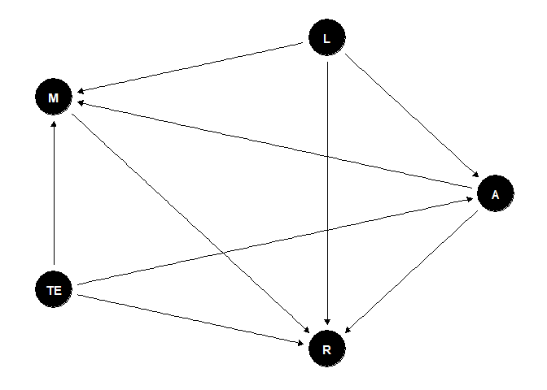

```r
# Diagrama causal de hipótesis con variables de interés y sus relaciones

library(ggdag)
dagified <- dagify(R ~ M, R ~ L, R ~ TE, R ~ A, M ~ TE, A ~ TE, A ~ L, M ~ L, M ~ A,
                   exposure = "M",
                   outcome = "R")

ggdag(dagified, layout = "circle") + theme_dag()
```

## 3. ¿De dónde vienen los datos?

Cómo se mencionó en el apartado 1, estos son datos reales tomados por el equipo de TEAM (http://www.teamnetwork.org) quienes colaboran con la ciencia abierta y suben a la web su base de datos para que pueda ser utilizada por investigadores y estudiantes.

A continuación la preparación de la base de datos para los análisis:

```r
# set de datos
dat <- read.csv("barva.csv", header = T, sep = ',')
head(dat)
```

```
##      ID    Site.Name Sampling.Unit.Name Latitude Longitude Sampling.Period
## 1 47902 Volcan Barva          CT-VB-1-1 10.42231  -84.0212         2007.01
## 2 48073 Volcan Barva          CT-VB-1-1 10.42231  -84.0212         2007.01
## 3 48012 Volcan Barva          CT-VB-1-1 10.42231  -84.0212         2007.01
## 4 47918 Volcan Barva          CT-VB-1-1 10.42231  -84.0212         2007.01
## 5 47953 Volcan Barva          CT-VB-1-1 10.42231  -84.0212         2007.01
## 6 48094 Volcan Barva          CT-VB-1-1 10.42231  -84.0212         2007.01
##   Photo.Type Photo.Date Photo.Time     Raw.Name Photo.Notes
## 1     Animal 22/04/2008   12:58:20 IMG_0002.JPG
## 2     Animal 22/04/2008   12:58:22 IMG_0003.JPG
## 3     Animal 22/04/2008   12:58:23 IMG_0004.JPG
## 4     Animal 22/04/2008   14:05:53 IMG_0005.JPG
## 5     Animal 22/04/2008   14:05:54 IMG_0006.JPG
## 6     Animal 22/04/2008   14:08:21 IMG_0007.JPG
##                                                                        Photo.ID.URL
```

[output cut: 62 more lines]

```r
# primero hacemos un subset con las variables de interés
barva <- dat[c(8, 15:18, 29, 30)]
head(barva)
```

```
##   Photo.Date      Family  Genus Species Number.of.Animals Moon.Phase
## 1 22/04/2008 TAYASSUIDAE Pecari  tajacu                 1          4
## 2 22/04/2008 TAYASSUIDAE Pecari  tajacu                 1          4
## 3 22/04/2008 TAYASSUIDAE Pecari  tajacu                 1          4
## 4 22/04/2008 TAYASSUIDAE Pecari  tajacu                 2          4
## 5 22/04/2008 TAYASSUIDAE Pecari  tajacu                 2          4
## 6 22/04/2008 TAYASSUIDAE Pecari  tajacu                 1          4
##   Temperature
## 1          27
## 2          27
## 3          27
## 4          27
## 5          27
## 6          27
```

```r
# cambiamos los nombres de las variables
names(barva) <- c("fecha","familia", "genero", "especie", "abund", "luna", "temp")
head(barva)
```

```
##        fecha     familia genero especie abund luna temp
## 1 22/04/2008 TAYASSUIDAE Pecari  tajacu     1    4   27
## 2 22/04/2008 TAYASSUIDAE Pecari  tajacu     1    4   27
## 3 22/04/2008 TAYASSUIDAE Pecari  tajacu     1    4   27
## 4 22/04/2008 TAYASSUIDAE Pecari  tajacu     2    4   27
## 5 22/04/2008 TAYASSUIDAE Pecari  tajacu     2    4   27
## 6 22/04/2008 TAYASSUIDAE Pecari  tajacu     1    4   27
```

```r
str(barva)
```

```
## 'data.frame':    45886 obs. of  7 variables:
##  $ fecha  : chr  "22/04/2008" "22/04/2008" "22/04/2008" "22/04/2008" ...
##  $ familia: chr  "TAYASSUIDAE" "TAYASSUIDAE" "TAYASSUIDAE" "TAYASSUIDAE" ...
##  $ genero : chr  "Pecari" "Pecari" "Pecari" "Pecari" ...
##  $ especie: chr  "tajacu" "tajacu" "tajacu" "tajacu" ...
##  $ abund  : int  1 1 1 2 2 1 1 1 1 1 ...
##  $ luna   : chr  "4" "4" "4" "4" ...
##  $ temp   : int  27 27 27 27 27 27 27 28 28 28 ...
```

```r
# cambiamos formato de variables
barva$fecha <- as.factor(barva$fecha)
barva$fecha <- as.POSIXlt(strptime(as.character(barva$fecha), "%d/%m/%Y"))
barva$fecha <- as.POSIXct(barva$fecha, origin = "1960/01/01", tz = "UTC")

# hacemos nueva columna para mes
barva$mes <- format(as.Date(barva$fecha), "%b")
barva$mes <- as.factor(barva$mes)
levels(barva$mes)
```

```
## [1] "Apr" "Aug" "Feb" "Jan" "Jul" "Jun" "Mar" "May"
```

```r
# ordenamos meses
barva$mes <- factor(barva$mes,levels= c("Jan", "Feb", "Mar", "Apr", "May", "Jun", "Jul", "Aug"))
levels(barva$mes)
```

```
## [1] "Jan" "Feb" "Mar" "Apr" "May" "Jun" "Jul" "Aug"
```

```r
# hacemos nueva columna para año
barva$año <- format(as.Date(barva$fecha), "%Y")
barva$año <- as.factor(barva$año)
levels(barva$año)
```

```
##  [1] "2008" "2009" "2010" "2011" "2012" "2013" "2014" "2015" "2016" "2017"
```

```r
# hacemos nueva columna con codigo de especie
barva$spp <- paste(substr(barva$genero, 1, 1), substr(barva$especie, 1, 3), sep = "")
barva$spp <- as.factor(barva$spp)
levels(barva$spp)
```

```
##  [1] "Bsum" "Ccap" "Cder" "Clup" "Cpac" "Csem" "Ddog" "Dmar" "Dnov" "Dpun"
## [11] "Ebar" "Hsap" "Lpar" "Ltig" "Lwie" "Mmex" "Mnud" "Mtem" "Nnar" "Ovir"
## [21] "Pcon" "Plot" "Ponc" "Popo" "Psem" "Ptaj" "Pyag" "Sgra" "Smex" "Svar"
## [31] "Tbai" "Tmex"
```

```r
# arreglamos diferencia de codigos en variable luna
barva$luna <- as.factor(barva$luna)
levels(barva$luna)
```

```
##  [1] "0"              "1"              "2"              "3"
##  [5] "4"              "5"              "6"              "7"
##  [9] "First Quarter"  "Full"           "Last Quarter"   "New"
## [13] "New Crescent"   "Old Crescent"   "Waning Gibbous" "Waxing Gibbous"
```

```r
levels(barva$luna) <- c("New", "NCres", "FQua", "WaxG", "Full", "WanG", "LQua", "OCres", "FQua",
                        "Full", "LQua", "New", "NCres", "OCres", "WanG", "WaxG")
levels(barva$luna)
```

```
## [1] "New"   "NCres" "FQua"  "WaxG"  "Full"  "WanG"  "LQua"  "OCres"
```

```r
# quitamos valores extraños de temperatura que no estan en base de datos original
barva <- subset(barva, barva$temp>7)
barva <- subset(barva, barva$temp<33)

# revisamos cambios
head(barva)
```

```
##        fecha     familia genero especie abund luna temp mes  año  spp
## 1 2008-04-22 TAYASSUIDAE Pecari  tajacu     1 Full   27 Apr 2008 Ptaj
## 2 2008-04-22 TAYASSUIDAE Pecari  tajacu     1 Full   27 Apr 2008 Ptaj
## 3 2008-04-22 TAYASSUIDAE Pecari  tajacu     1 Full   27 Apr 2008 Ptaj
## 4 2008-04-22 TAYASSUIDAE Pecari  tajacu     2 Full   27 Apr 2008 Ptaj
## 5 2008-04-22 TAYASSUIDAE Pecari  tajacu     2 Full   27 Apr 2008 Ptaj
## 6 2008-04-22 TAYASSUIDAE Pecari  tajacu     1 Full   27 Apr 2008 Ptaj
```

```r
str(barva)
```

```
## 'data.frame':    45660 obs. of  10 variables:
##  $ fecha  : POSIXct, format: "2008-04-22" "2008-04-22" ...
##  $ familia: chr  "TAYASSUIDAE" "TAYASSUIDAE" "TAYASSUIDAE" "TAYASSUIDAE" ...
##  $ genero : chr  "Pecari" "Pecari" "Pecari" "Pecari" ...
##  $ especie: chr  "tajacu" "tajacu" "tajacu" "tajacu" ...
##  $ abund  : int  1 1 1 2 2 1 1 1 1 1 ...
##  $ luna   : Factor w/ 8 levels "New","NCres",..: 5 5 5 5 5 5 5 5 5 5 ...
##  $ temp   : int  27 27 27 27 27 27 27 28 28 28 ...
##  $ mes    : Factor w/ 8 levels "Jan","Feb","Mar",..: 4 4 4 4 4 4 4 4 4 4 ...
##  $ año    : Factor w/ 10 levels "2008","2009",..: 1 1 1 1 1 1 1 1 1 1 ...
##  $ spp    : Factor w/ 32 levels "Bsum","Ccap",..: 26 26 26 26 26 26 26 26 26 26 ...
```

```r
# generamos una nueva base que contenga riqueza de especies
library(plyr)
barva2 <- ddply(barva, .(año, mes, luna, temp), summarize,
                riqsp = length(unique(spp)))
head(barva2)
```

```
##    año mes luna temp riqsp
## 1 2008 Apr Full   27     1
## 2 2008 Apr Full   28     1
## 3 2008 Apr WanG   20     1
## 4 2008 Apr WanG   21     1
## 5 2008 Apr WanG   22     2
## 6 2008 Apr WanG   23     3
```

```r
# ordenamos la base por año y mes
barva2 <- barva2[order(barva2$año, barva2$mes), ]
head(barva2)
```

```
##    año mes luna temp riqsp
## 1 2008 Apr Full   27     1
## 2 2008 Apr Full   28     1
## 3 2008 Apr WanG   20     1
## 4 2008 Apr WanG   21     1
## 5 2008 Apr WanG   22     2
## 6 2008 Apr WanG   23     3
```

## 4. Análisis de los datos

Ahora vamos a realizar una evaluación de los supuestos de la distribución de los datos

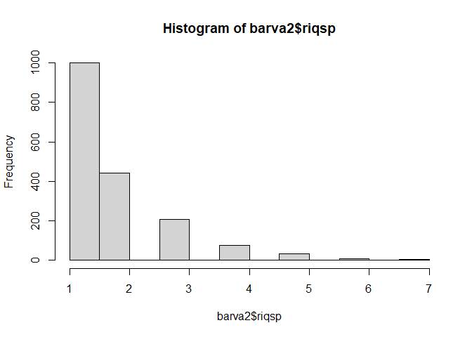

```r
# chequeamos distribucion de datos
hist(barva2$riqsp)
```

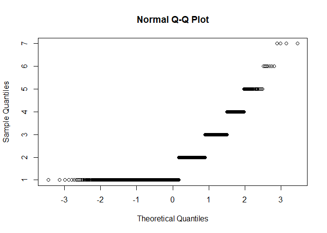

```r
qqnorm(barva2$riqsp)
```

```r
library(psych)
library(lme4)
```

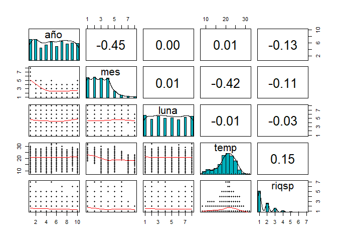

```r
library(sjPlot)
library(ggplot2)

pairs.panels(barva2,
             method = "pearson",
             hist.col = "#00AFBB",
             density = T,
             ellipses = F)
```

Observamos que la riqueza de especies de mamíferos al ser un conteo, parece ajustarse a una distribución Poisson, además vemos que posiblemente hay relaciones no lineales con las variables predictoras.

Para determinar si un GAMM es más apropiado, vamos a realizar también un GLMM y determinaremos el modelo con mejor ajuste con el criterio de información de Akaike (AIC).

```r
## Modelos GLMM (con distribucion Poisson)

# Modelo nulo
m0 <- glmer(riqsp ~ 1 + (1 | año), data = barva2, family = poisson(link = "log"))
summary(m0)
```

```
## Generalized linear mixed model fit by maximum likelihood (Laplace
##   Approximation) [glmerMod]
##  Family: poisson  ( log )
## Formula: riqsp ~ 1 + (1 | año)
##    Data: barva2
##
##      AIC      BIC   logLik deviance df.resid
##   5080.5   5091.4  -2538.2   5076.5     1764
##
## Scaled residuals:
##     Min      1Q  Median      3Q     Max
## -0.6715 -0.5597 -0.4634  0.2569  3.9916
##
## Random effects:
##  Groups Name        Variance Std.Dev.
##  año    (Intercept) 0.005941 0.07708
## Number of obs: 1766, groups:  año, 10
##
## Fixed effects:
##             Estimate Std. Error z value Pr(>|z|)
## (Intercept)  0.53321    0.03063   17.41   <2e-16 ***
## ---
## Signif. codes:  0 '***' 0.001 '**' 0.01 '*' 0.05 '.' 0.1 ' ' 1
```

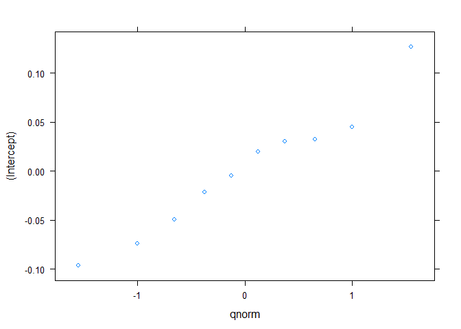

```r
plot(ranef(m0))
```

```r
#Modelo con predictores
m1 <- glmer(riqsp ~ mes + luna + temp + (1 | año), data = barva2, family = poisson(link = "log"))
summary(m1)
```

```
## Generalized linear mixed model fit by maximum likelihood (Laplace
##   Approximation) [glmerMod]
##  Family: poisson  ( log )
## Formula: riqsp ~ mes + luna + temp + (1 | año)
##    Data: barva2
##
##      AIC      BIC   logLik deviance df.resid
##   5006.6   5099.7  -2486.3   4972.6     1749
##
## Scaled residuals:
##     Min      1Q  Median      3Q     Max
## -1.0990 -0.5207 -0.1958  0.2958  3.8469
##
## Random effects:
##  Groups Name        Variance Std.Dev.
##  año    (Intercept) 0.0358   0.1892
## Number of obs: 1766, groups:  año, 10
##
## Fixed effects:
##              Estimate Std. Error z value Pr(>|z|)
## (Intercept)  0.962733   0.161760   5.952 2.66e-09 ***
## mesFeb      -0.134699   0.054190  -2.486 0.012929 *
## mesMar      -0.156429   0.057441  -2.723 0.006463 **
## mesApr      -0.508884   0.073093  -6.962 3.35e-12 ***
## mesMay      -0.440219   0.120315  -3.659 0.000253 ***
## mesJun      -0.287466   0.158665  -1.812 0.070020 .
## mesJul      -1.036632   0.214998  -4.822 1.42e-06 ***
## mesAug      -1.083836   0.225270  -4.811 1.50e-06 ***
## lunaNCres   -0.057233   0.070412  -0.813 0.416312
## lunaFQua    -0.110066   0.069146  -1.592 0.111429
## lunaWaxG    -0.137932   0.071802  -1.921 0.054730 .
## lunaFull    -0.099400   0.070307  -1.414 0.157425
## lunaWanG    -0.111081   0.072685  -1.528 0.126447
## lunaLQua    -0.094892   0.069727  -1.361 0.173539
## lunaOCres   -0.077751   0.068143  -1.141 0.253874
## temp        -0.006127   0.005714  -1.072 0.283548
## ---
## Signif. codes:  0 '***' 0.001 '**' 0.01 '*' 0.05 '.' 0.1 ' ' 1
```

```
##
## Correlation matrix not shown by default, as p = 16 > 12.
## Use print(x, correlation=TRUE)  or
##     vcov(x)        if you need it
```

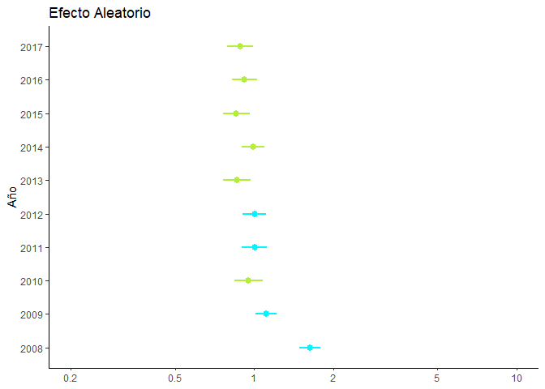

```r
p1 <- plot_model(m1, type = "re", title= "Efecto Aleatorio", colors = c("olivedrab2", "turquoise1"),
                   line.size = 1)+ xlab("Año") + theme_classic()
p1
```

```r
AIC(m0, m1) #el valor de AIC de nuestro modelo debe ser menor al modelo nulo para ser
```

```
##    df      AIC
## m0  2 5080.486
## m1 17 5006.630
```

```r
library(blmeco)
dispersion_glmer(m1) #no hay sobredispersion (menor a 1.4)
```

```
## [1] 0.6636153
```

```r
## Modelos GAMM (con distribucion Poisson)
library(gamm4)
# Modelo nulo
mg0 <- gamm4(riqsp ~ 1, data = barva2, family = poisson(link = "log"),
              random = ~ (1 | año))

# Modelo con predictores
mg1 <- gamm4(riqsp ~ mes + luna + s(temp), data = barva2, family = poisson(link = "log"),
              random = ~ (1 | año))
summary(mg1$gam)
```

```
##
## Family: poisson
## Link function: log
##
## Formula:
## riqsp ~ mes + luna + s(temp)
##
## Parametric coefficients:
##             Estimate Std. Error z value Pr(>|z|)
## (Intercept)  0.76539    0.07468  10.249  < 2e-16 ***
## mesFeb      -0.14762    0.05397  -2.735 0.006237 **
## mesMar      -0.13485    0.05646  -2.388 0.016919 *
## mesApr      -0.33236    0.07047  -4.716  2.4e-06 ***
## mesMay      -0.21182    0.10146  -2.088 0.036826 *
## mesJun      -0.14673    0.12906  -1.137 0.255572
## mesJul      -0.67229    0.18968  -3.544 0.000394 ***
## mesAug      -0.69970    0.20060  -3.488 0.000486 ***
## lunaNCres   -0.07143    0.07050  -1.013 0.310954
## lunaFQua    -0.13129    0.06920  -1.897 0.057808 .
## lunaWaxG    -0.14544    0.07185  -2.024 0.042937 *
## lunaFull    -0.12348    0.07041  -1.754 0.079471 .
## lunaWanG    -0.14615    0.07272  -2.010 0.044449 *
## lunaLQua    -0.11457    0.06976  -1.642 0.100507
## lunaOCres   -0.07964    0.06821  -1.167 0.243017
## ---
## Signif. codes:  0 '***' 0.001 '**' 0.01 '*' 0.05 '.' 0.1 ' ' 1
##
## Approximate significance of smooth terms:
##           edf Ref.df Chi.sq p-value
## s(temp) 5.579  5.579  103.4  <2e-16 ***
## ---
## Signif. codes:  0 '***' 0.001 '**' 0.01 '*' 0.05 '.' 0.1 ' ' 1
##
## R-sq.(adj) =  0.164
## glmer.ML = 661.81  Scale est. = 1         n = 1766
```

```r
AIC(m1, mg0$mer, mg1$mer) #elegimos el modelo con menor valor de AIC ya que es el que mejor se ajusta a los datos
```

```
##         df      AIC
## m1      17 5006.630
## mg0$mer  2 5080.486
## mg1$mer 18 4918.936
```

```r
# Nos quedamos con el GAMM mg1
```

Ahora buscamos el mejor modelo:

```r
mg2 <- gamm4(riqsp ~ mes + s(temp), data = barva2, family = poisson(link = "log"),
              random = ~ (1 | año))
mg3 <- gamm4(riqsp ~ luna + s(temp), data = barva2, family = poisson(link = "log"),
              random = ~ (1 | año))
mg4 <- gamm4(riqsp ~ s(temp), data = barva2, family = poisson(link = "log"),
              random = ~ (1 | año))

AIC(mg1$mer, mg2$mer, mg3$mer, mg4$mer) # buscamos el valor más bajo AIC
```

```
##         df      AIC
## mg1$mer 18 4918.936
## mg2$mer 11 4911.851
## mg3$mer 11 4937.600
## mg4$mer  4 4931.979
```

```r
# Elegimos el modelo 2 con mes y temperatura
summary(mg2$gam)
```

```
##
## Family: poisson
## Link function: log
##
## Formula:
## riqsp ~ mes + s(temp)
##
## Parametric coefficients:
##             Estimate Std. Error z value Pr(>|z|)
## (Intercept)  0.67062    0.06090  11.013  < 2e-16 ***
## mesFeb      -0.15446    0.05386  -2.868 0.004132 **
## mesMar      -0.13492    0.05643  -2.391 0.016800 *
## mesApr      -0.33938    0.07032  -4.826 1.39e-06 ***
## mesMay      -0.21693    0.10094  -2.149 0.031626 *
## mesJun      -0.14549    0.12845  -1.133 0.257377
## mesJul      -0.68720    0.18908  -3.635 0.000279 ***
## mesAug      -0.69397    0.19912  -3.485 0.000492 ***
## ---
## Signif. codes:  0 '***' 0.001 '**' 0.01 '*' 0.05 '.' 0.1 ' ' 1
##
## Approximate significance of smooth terms:
##           edf Ref.df Chi.sq p-value
## s(temp) 5.538  5.538  101.4  <2e-16 ***
## ---
## Signif. codes:  0 '***' 0.001 '**' 0.01 '*' 0.05 '.' 0.1 ' ' 1
##
## R-sq.(adj) =  0.159
## glmer.ML =  669.1  Scale est. = 1         n = 1766
```

Por último, utilizando nuestro modelo mg2 realizamos predicciones de la riqueza de especies de mamíferos en el gradiente del volcán Barva estacionalmente por mes y tomando en cuenta la variación en la temperatura:

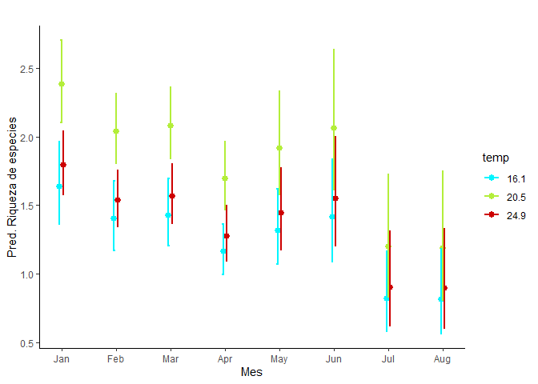

```r
## PREDICCIONES DEL MODELO mg2 CON MEJOR AJUSTE

# Para la riqueza de especies de mamíferos en el Barva

pm1 <- plot_model(mg2$gam, type = "pred", terms = c("mes", "temp"), title= "",
                   colors = c("turquoise1", "olivedrab2", "red3"), line.size = 1)+
  xlab("Mes") + ylab("Pred. Riqueza de especies")+ theme_classic()
pm1
```

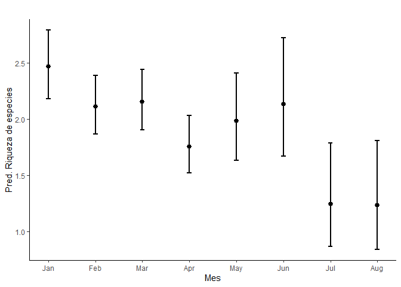

```r
pm2 <- plot_model(mg2$gam, type = "pred", terms = c("mes"), title= "",
                   colors = c("turquoise1"), line.size = 1)+
  xlab("Mes") + ylab("Pred. Riqueza de especies")+ theme_classic()
pm2
```

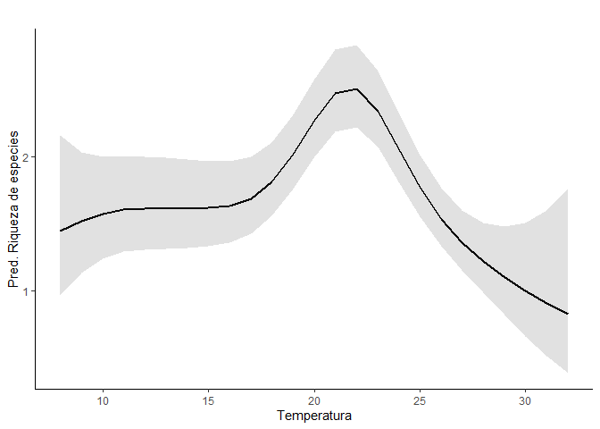

```r
pm3 <- plot_model(mg2$gam, type = "pred", terms = c("temp"), title= "",
                   colors = c("turquoise1"), line.size = 1)+
  xlab("Temperatura") + ylab("Pred. Riqueza de especies")+ theme_classic()
pm3
```

## 5. Interpretación de resultados

Encontramos una variación estacional, medida por mes, de la riqueza de especies de mamíferos presentes en el gradiente del Volcán Barva-Caribe. Según nuestro mejor modelo, se observa el mayor efecto en los meses de julio (estimado=-0.69) y agosto (estimado=-0.69), con una disminución en el número de especies presentes en el Barva, lo cual podría asociarse al inicio de los meses más lluviosos del año. Muchos mamíferos herbívoros suelen migrar estacionalmente dependiendo de las precipitaciones y la consiguiente disponibilidad de alimento, mientras que los depredadores siempre seguirán a sus presas (Altrichter et al. 2000). Además, en este modelo confirmamos la importancia de un factor ambiental como temperatura para la presencia de especies de mamíferos. Cómo podemos observar en nuestro gráfico predictivo, temperaturas intermedias entre 20°C-25°C favorecen el número de especies. En cuanto a la fase lunar, si bien no mostró suficiente peso para incluirse en el mejor modelo, se ha reportado ampliamente su influencia sobre los patrones de actividad y por lo tanto sobre la posibilidad de detección de mamíferos nocturnos y catemerales (Botts et al. 2020). No obstante, este modelo sólo explica el 16% de los datos y cabe resaltar que hay variables ambientales de peso que no se incluyeron como precipitación y elevación, además de variables antropogénicas como cercanía a carreteras, cultivos, que pueden tener un efecto crucial en cuanto a la estabilidad y movimiento de estas especies de mamíferos medianas y grandes que por sus requerimientos ecológicos (territorio, reproducción, alimentación) necesitan movilizarse periódicamente a través de extensiones considerables de bosque (Bogoni et al. 2020).

Agradecimiento y con el debido reconocimiento de:

Tropical Ecology, Assessment and Monitoring (TEAM) Network Conservation International 2011 Crystal Drive, Suite 500 Arlington, Virginia 22202, United States (703) 341-2400 (voice) http://www.teamnetwork.org

**Referencias**

Altrichter M, Sáenz JC, Carrillo E. 2000. Dieta estacional del Tayassu pecari (Artiodactyla: Tayassuidae) en el Parque Nacional Corcovado, Costa Rica. Revista de Biología Tropical **48**:689–702.

Bogoni JA, Peres CA, Ferraz KMPMB. 2020. Effects of mammal defaunation on natural ecosystem services and human well being throughout the entire Neotropical realm. Ecosystem Services **45**:101173. Elsevier B.V. Available from https://doi.org/10.1016/j.ecoser.2020.101173.

Botts RT et al. 2020. Circadian activity patterns of mammalian predators and prey in Costa Rica. Journal of Mammalogy:1–19.